# wk12

zimeng

2019/4/4

```r
head(USJudgeRatings)
```

```
##                CONT INTG DMNR DILG CFMG DECI PREP FAMI ORAL WRIT PHYS RTEN
## AARONSON,L.H.   5.7  7.9  7.7  7.3  7.1  7.4  7.1  7.1  7.1  7.0  8.3  7.8
## ALEXANDER,J.M.  6.8  8.9  8.8  8.5  7.8  8.1  8.0  8.0  7.8  7.9  8.5  8.7
## ARMENTANO,A.J.  7.2  8.1  7.8  7.8  7.5  7.6  7.5  7.5  7.3  7.4  7.9  7.8
## BERDON,R.I.     6.8  8.8  8.5  8.8  8.3  8.5  8.7  8.7  8.4  8.5  8.8  8.7
## BRACKEN,J.J.    7.3  6.4  4.3  6.5  6.0  6.2  5.7  5.7  5.1  5.3  5.5  4.8
## BURNS,E.B.      6.2  8.8  8.7  8.5  7.9  8.0  8.1  8.0  8.0  8.0  8.6  8.6
```

```r
?USJudgeRatings
```

## Exercise 1 (R output required)

## 1

**Let’s check the linear regression assumptions that we can test prior to running the linear model. First, check and tell us whether the x and y variables are linearly related. Next, please check and tell us whether the y variable is normally distributed. As a reminder, having a normally distributed y variable is not a specific assumption for a linear regression, but we can use it as a proxy to understand whether our errors will likely be normally distributed (which is an assumption of the linear regression!).**

1. y variable: CONT x variable: INTG+DMNR According to plots, x and y variables are not linearly related.

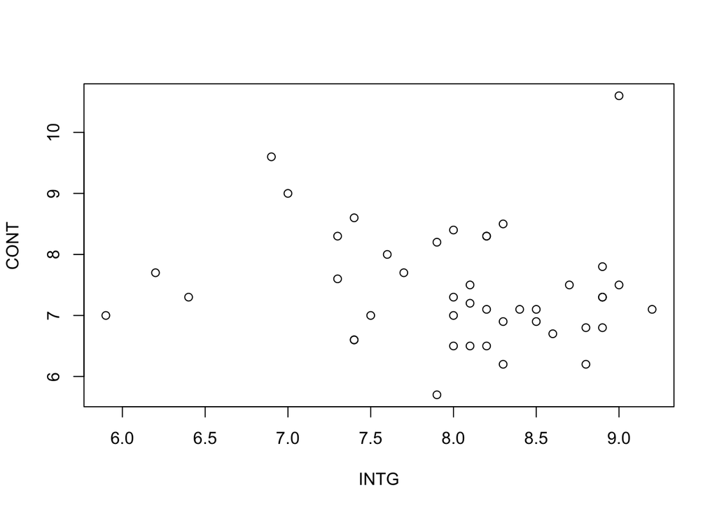

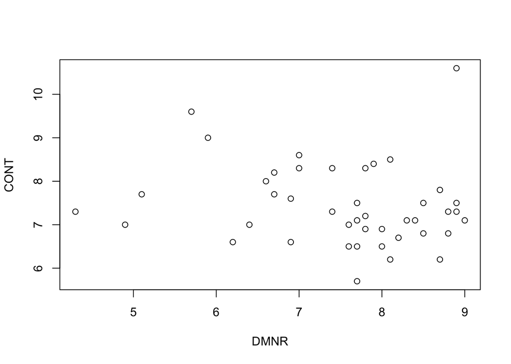

```r
plot(CONT~INTG+DMNR,data=USJudgeRatings)
```

(2)normality

```r
shapiro.test(USJudgeRatings$CONT)
```

```
##
##  Shapiro-Wilk normality test
##
## data:  USJudgeRatings$CONT
## W = 0.93274, p-value = 0.01445
```

p value is below 0.05. So null hypothsis that CONT are normally distributed is rejected. So y variables are not normally distributed.

## 2

**Now run the linear regression and check the remaining assumptions. Are the errors homoscedastic and normally distributed? To test for homoscedasticity, you can use the Breusch-Pagan test in the lmtest package. To check for normality, you should use the shapiro wilk test and plot a qqplot.**

```r
lmmod1 = lm(CONT~INTG+DMNR,data=USJudgeRatings)
summary(lmmod1)
```

```
##
## Call:
## lm(formula = CONT ~ INTG + DMNR, data = USJudgeRatings)
##
## Residuals:
##     Min      1Q  Median      3Q     Max
## -1.6504 -0.6444 -0.1735  0.4421  3.3165
##
## Coefficients:
##             Estimate Std. Error t value Pr(>|t|)
## (Intercept)   7.5568     2.4692   3.060  0.00394 **
## INTG          0.2647     0.7227   0.366  0.71615
## DMNR         -0.2983     0.4867  -0.613  0.54333
## ---
## Signif. codes:  0 '***' 0.001 '**' 0.01 '*' 0.05 '.' 0.1 ' ' 1
##
## Residual standard error: 0.9511 on 40 degrees of freedom
## Multiple R-squared:  0.02688,    Adjusted R-squared:  -0.02177
## F-statistic: 0.5525 on 2 and 40 DF,  p-value: 0.5798
```

```r
library(car)
library(lmtest)
```

**homoscedastic**

```r
bptest(lmmod1)
```

```
##
##  studentized Breusch-Pagan test
##
## data:  lmmod1
## BP = 0.18159, df = 2, p-value = 0.9132
```

```r
ncvTest(lmmod1)
```

```
## Non-constant Variance Score Test
## Variance formula: ~ fitted.values
## Chisquare = 0.378373, Df = 1, p = 0.53848
```

In Breusch-Pagan test, p-value = 0.9132. P -value is greater than 0.05. In the Non-constant Variance Score Test, p=0.53848. Both of these results show that our p-value is > 0.05, therefore we fail to reject the null hypothesis of homoscedasticity, and our residuals are homoscedastic.

**normality of errors**

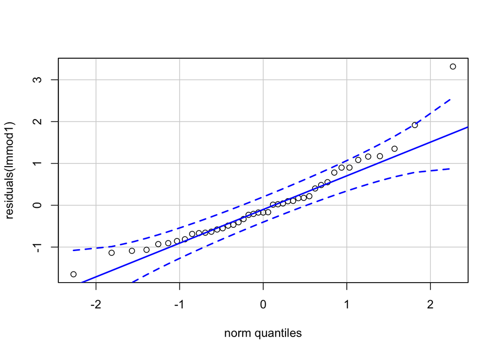

```r
qqPlot(residuals(lmmod1),id=FALSE)
```

```r
shapiro.test(residuals(lmmod1))
```

```
##
##  Shapiro-Wilk normality test
##
## data:  residuals(lmmod1)
## W = 0.92583, p-value = 0.00839
```

**GLM**

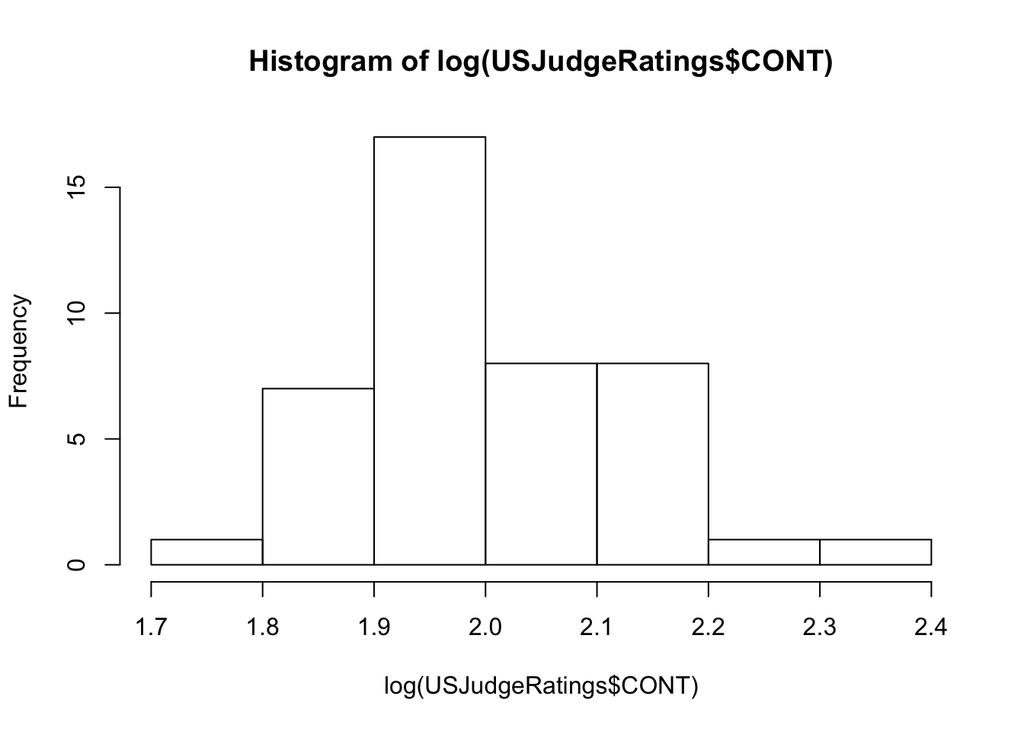

```r
hist(log(USJudgeRatings$CONT))
```

## Exercise 2 (R output required)

**Are the errors of this new model lmmod2 homoscedastic and normally distributed? To test for homoscedasticity, you can use the Breusch-Pagan test in the lmtest package. To check for normality, you should use the shapiro wilk test and plot a qqplot.**

```r
lmmod2 = lm(log(CONT)~INTG+DMNR,data=USJudgeRatings)
summary(lmmod2)
```

```
##
## Call:
## lm(formula = log(CONT) ~ INTG + DMNR, data = USJudgeRatings)
##
## Residuals:
##      Min       1Q   Median       3Q      Max
## -0.24610 -0.08189 -0.01590  0.06446  0.38296
##
## Coefficients:
##             Estimate Std. Error t value Pr(>|t|)
## (Intercept)  2.00946    0.31676   6.344 1.55e-07 ***
## INTG         0.03890    0.09271   0.420    0.677
## DMNR        -0.04288    0.06243  -0.687    0.496
## ---
## Signif. codes:  0 '***' 0.001 '**' 0.01 '*' 0.05 '.' 0.1 ' ' 1
##
## Residual standard error: 0.122 on 40 degrees of freedom
## Multiple R-squared:  0.03198,    Adjusted R-squared:  -0.01642
## F-statistic: 0.6607 on 2 and 40 DF,  p-value: 0.522
```

**homoscedasticity**

```r
bptest(lmmod2)
```

```
##
##  studentized Breusch-Pagan test
##
## data:  lmmod2
## BP = 0.27715, df = 2, p-value = 0.8706
```

In Breusch-Pagan test, p-value = 0.8706. P -value is greater than 0.05.Therefore we fail to reject the null hypothesis of homoscedasticity, and our residuals are homoscedastic.

**normality of errors**

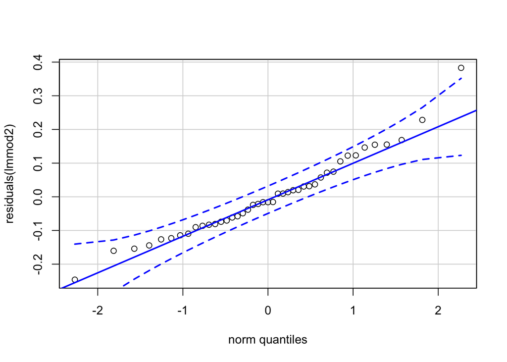

```r
qqPlot(residuals(lmmod2),id=FALSE)
```

```r
shapiro.test(residuals(lmmod2))
```

```
##
##  Shapiro-Wilk normality test
##
## data:  residuals(lmmod2)
## W = 0.96329, p-value = 0.1827
```

Most part of residuals fall within the dotted blue lines, and p-value is larger than 0.05. So the null hypothsis that errors are normally distributed is not rejected. Errors are normally distributed.

**Binomial data (logistic regression)**

```r
well <- read.csv("wells.csv")
head(well)
```

```
##   switch arsenic   dist assoc educ
## 1      1    2.36 16.826     0    0
## 2      1    0.71 47.322     0    0
## 3      0    2.07 20.967     0   10
## 4      1    1.15 21.486     0   12
## 5      1    1.10 40.874     1   14
## 6      1    3.90 69.518     1    9
```

```r
cor(well)
```

```
##              switch     arsenic         dist        assoc        educ
## switch   1.00000000  0.18386827 -0.117941730 -0.035914753  0.07637076
## arsenic  0.18386827  1.00000000  0.178057697 -0.024911525 -0.02956287
## dist    -0.11794173  0.17805770  1.000000000 -0.003460305 -0.02674095
## assoc   -0.03591475 -0.02491153 -0.003460305  1.000000000 -0.03136667
## educ     0.07637076 -0.02956287 -0.026740946 -0.031366669  1.00000000
```

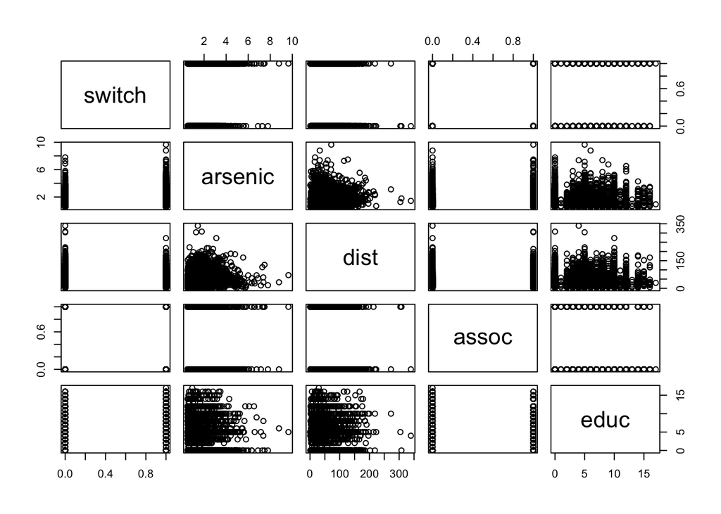

```r
pairs(well)
```

```r
mod1 <- glm(switch ~ arsenic, data = well, family = binomial(link = "logit"))
summary(mod1)
```

```
##
## Call:
## glm(formula = switch ~ arsenic, family = binomial(link = "logit"),
##     data = well)
##
## Deviance Residuals:
##    Min      1Q  Median      3Q     Max
## -2.331  -1.201   0.822   1.097   1.225
##
## Coefficients:
##             Estimate Std. Error z value Pr(>|z|)
## (Intercept) -0.30553    0.07030  -4.346 1.39e-05 ***
## arsenic      0.37914    0.03853   9.840  < 2e-16 ***
## ---
## Signif. codes:  0 '***' 0.001 '**' 0.01 '*' 0.05 '.' 0.1 ' ' 1
##
## (Dispersion parameter for binomial family taken to be 1)
##
##     Null deviance: 4118.1  on 3019  degrees of freedom
## Residual deviance: 4008.7  on 3018  degrees of freedom
## AIC: 4012.7
##
## Number of Fisher Scoring iterations: 4
```

```r
mod2 <- glm(switch ~ arsenic, data = well, family = binomial)
summary(mod2)
```

```
##
## Call:
## glm(formula = switch ~ arsenic, family = binomial, data = well)
##
## Deviance Residuals:
##    Min      1Q  Median      3Q     Max
## -2.331  -1.201   0.822   1.097   1.225
##
## Coefficients:
##             Estimate Std. Error z value Pr(>|z|)
## (Intercept) -0.30553    0.07030  -4.346 1.39e-05 ***
## arsenic      0.37914    0.03853   9.840  < 2e-16 ***
## ---
## Signif. codes:  0 '***' 0.001 '**' 0.01 '*' 0.05 '.' 0.1 ' ' 1
##
## (Dispersion parameter for binomial family taken to be 1)
##
##     Null deviance: 4118.1  on 3019  degrees of freedom
## Residual deviance: 4008.7  on 3018  degrees of freedom
## AIC: 4012.7
##
## Number of Fisher Scoring iterations: 4
```

```r
exp(0.37914)
```

```
## [1] 1.461028
```

## Exercise 3 (R output required)

## 1

**Please run a logistic regression where you estimate whether a household moves based on arsenic, dist, assoc, and educ. Which variables are significantly associated with whether a household moves or not (don’t interpret the variables at this stage)?**

```r
mod3 <- glm(switch ~ arsenic+dist+assoc+educ, data = well, family = binomial)
summary(mod3)
```

```
##
## Call:
## glm(formula = switch ~ arsenic + dist + assoc + educ, family = binomial,
##     data = well)
##
## Deviance Residuals:
##     Min       1Q   Median       3Q      Max
## -2.5942  -1.1976   0.7541   1.0632   1.6739
##
## Coefficients:
##              Estimate Std. Error z value Pr(>|z|)
## (Intercept) -0.156712   0.099601  -1.573    0.116
## arsenic      0.467022   0.041602  11.226  < 2e-16 ***
## dist        -0.008961   0.001046  -8.569  < 2e-16 ***
## assoc       -0.124300   0.076966  -1.615    0.106
## educ         0.042447   0.009588   4.427 9.55e-06 ***
## ---
## Signif. codes:  0 '***' 0.001 '**' 0.01 '*' 0.05 '.' 0.1 ' ' 1
##
## (Dispersion parameter for binomial family taken to be 1)
##
##     Null deviance: 4118.1  on 3019  degrees of freedom
## Residual deviance: 3907.8  on 3015  degrees of freedom
## AIC: 3917.8
##
## Number of Fisher Scoring iterations: 4
```

arsenic, dist,and edu are significantly associated with whether a household moves or not.

## 2

**Now let’s do the hard part! Backtransform all of your coefficients (on arsenic,dist,assoc,and educ) and write one sentence for each interpreting your coefficient in terms of odds. Please note the unit of x when you are writing out this sentence. As a reminder, arsenic, dist, and educ are continuous variables and assoc is a categorical variable (whether a household belonged to a community association, coded as 1, or not, coded as 0).**

**arsenic**

```r
exp(0.467022)
```

```
## [1] 1.595236
```

Odds of moving increase by 1.595236 for every ppm of arsenic in the water.

**dist**

```r
exp(-0.008961)
```

```
## [1] 0.991079
```

Odds of moving increase by 0.991079 for the distance in every hundred of meters of the household to the closest known safe well in hundreds of meters.

**assoc**

```r
exp(-0.124300)
```

```
## [1] 0.8831149
```

Odds of moving increase by 0.8831149 for every members of the household are active in community organizations.

**educ**

```r
exp(0.042447)
```

```
## [1] 1.043361
```

Odds of moving increase by 1.043361 for every education level (in years) of the head of household.

## 3

**Now modify the sentences above to state the % change in whether a household moves or not per unit change in each of the x variables. I know questions 2 + 3 may be challenging so please ask the GSIs for help!**

**arsenic**

```r
(exp(0.467022)-1)*100
```

```
## [1] 59.52365
```

for every ppm increase in arsenic, a household is 59.52365% more likely to move.

**dist**

```r
(exp(-0.008961)-1)*100
```

```
## [1] -0.892097
```

for every hundred of meters increase in the distance of the household to the closest known safe well in hundreds of meters，a household is -0.892097% more likely to move.

**assoc**

```r
(exp(-0.124300)-1)*100
```

```
## [1] -11.68851
```

If every members of the household are active in community organizations, a household is -11.68851% more likely to move.

**educ**

```r
(exp(0.042447)-1)*100
```

```
## [1] 4.336076
```

for every year increase in education level, a household is 4.336076% more likely to move.

## 4

**Extra Credit Using your knowledge of how to back transform log odds, read this webpage (https://data.library.virginia.edu/interpreting-log-transformations-in-a-linear-model/) and interpret the result from lmmod2, ‘for every 1 unit increase in integrity, there is a 0.0389 unit increase in the log of contacts.’ This is the result from our log transformed regression in the first section of this lab (remember, we are pretending this beta coefficient is significant even though in reality it is not significant).**

```r
exp(0.0389)
```

```
## [1] 1.039667
```

for every 1 unit increase in integrity, there is a 1.039667 unit increase in contacts.

## Count data (Poisson distribution)

```r
#install.packages('faraway')
library(faraway) # remember to install this package first!
data(gala)
head(gala)
```

```
##              Species Endemics  Area Elevation Nearest Scruz Adjacent
## Baltra            58       23 25.09       346     0.6   0.6     1.84
## Bartolome         31       21  1.24       109     0.6  26.3   572.33
## Caldwell           3        3  0.21       114     2.8  58.7     0.78
## Champion          25        9  0.10        46     1.9  47.4     0.18
## Coamano            2        1  0.05        77     1.9   1.9   903.82
## Daphne.Major      18       11  0.34       119     8.0   8.0     1.84
```

```r
cor(gala, use='complete.obs')
```

```
##               Species     Endemics       Area   Elevation      Nearest
## Species    1.00000000  0.970876516  0.6178431  0.73848666 -0.014094067
## Endemics   0.97087652  1.000000000  0.6169791  0.79290437  0.005994286
## Area       0.61784307  0.616979087  1.0000000  0.75373492 -0.111103196
## Elevation  0.73848666  0.792904369  0.7537349  1.00000000 -0.011076984
## Nearest   -0.01409407  0.005994286 -0.1111032 -0.01107698  1.000000000
## Scruz     -0.17114244 -0.154264319 -0.1007849 -0.01543829  0.615410357
## Adjacent   0.02616635  0.082658026  0.1800376  0.53645782 -0.116247885
##                 Scruz    Adjacent
## Species   -0.17114244  0.02616635
## Endemics  -0.15426432  0.08265803
## Area      -0.10078493  0.18003759
## Elevation -0.01543829  0.53645782
## Nearest    0.61541036 -0.11624788
## Scruz      1.00000000  0.05166066
## Adjacent   0.05166066  1.00000000
```

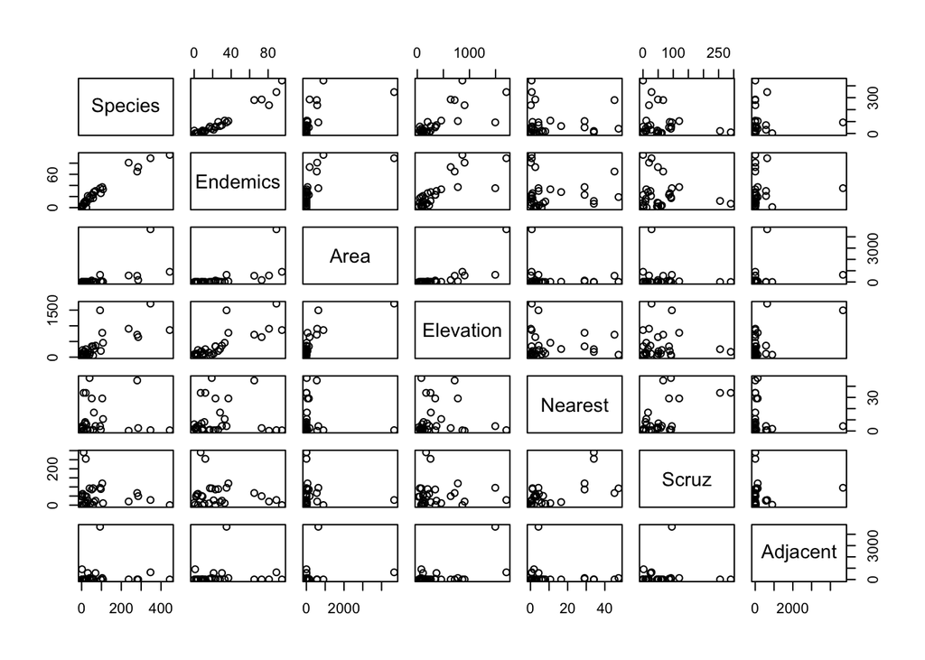

```r
pairs(gala)
```

```r
mod3 <- lm(Species ~ Area + Nearest + Adjacent, data = gala)
summary(mod3)
```

```
##
## Call:
## lm(formula = Species ~ Area + Nearest + Adjacent, data = gala)
##
## Residuals:
##     Min      1Q  Median      3Q     Max
## -103.66  -53.31  -35.18   23.30  305.12
##
## Coefficients:
##             Estimate Std. Error t value Pr(>|t|)
## (Intercept) 62.15560   22.98119   2.705 0.011901 *
## Area         0.08465    0.02072   4.085 0.000375 ***
## Nearest      0.37841    1.24235   0.305 0.763101
## Adjacent    -0.01104    0.02072  -0.533 0.598893
## ---
## Signif. codes:  0 '***' 0.001 '**' 0.01 '*' 0.05 '.' 0.1 ' ' 1
##
## Residual standard error: 94.45 on 26 degrees of freedom
## Multiple R-squared:  0.3914, Adjusted R-squared:  0.3212
## F-statistic: 5.573 on 3 and 26 DF,  p-value: 0.004334
```

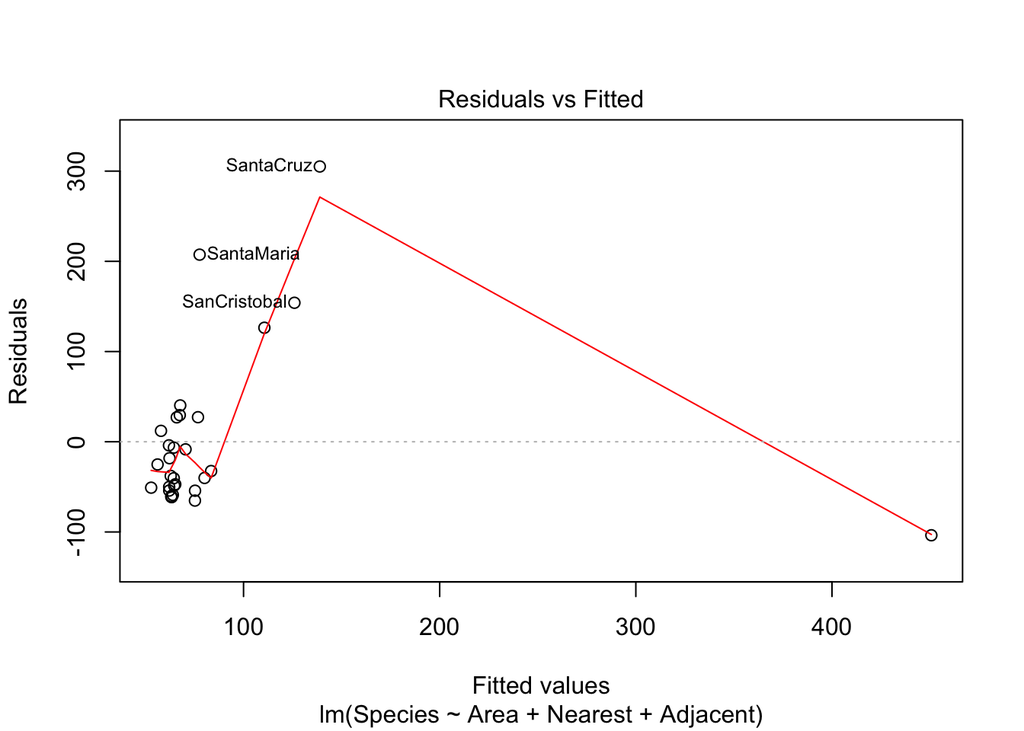

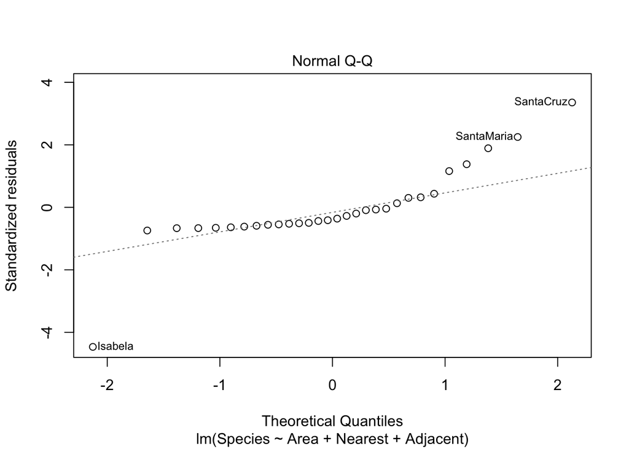

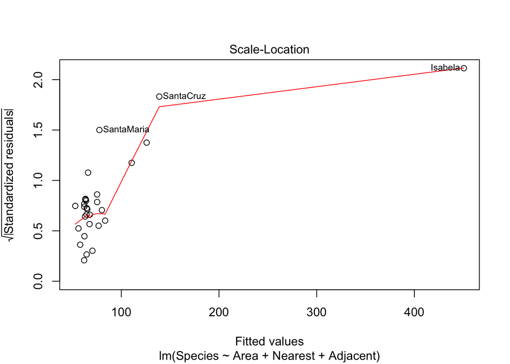

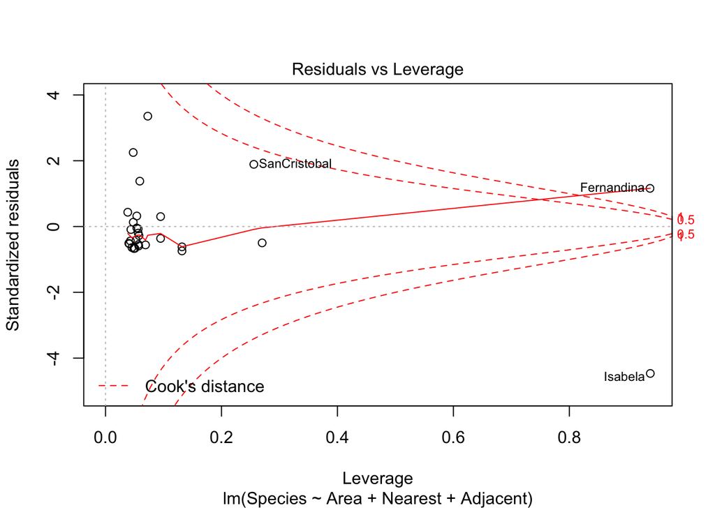

```r
plot(mod3)
```

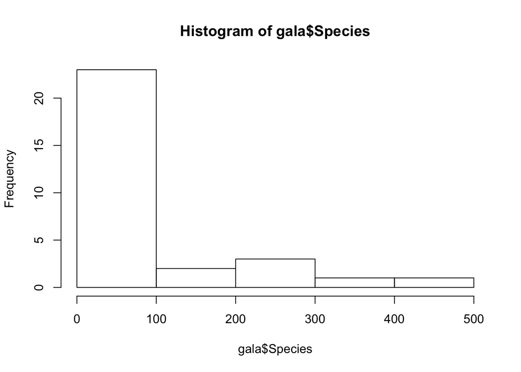

```r
hist(gala$Species)
```

```r
mean(gala$Species)
```

```
## [1] 85.23333
```

```r
mod4 <- glm(Species ~ Area + Nearest + Adjacent, data = gala, family = poisson(link = "log"))
summary(mod4)
```

```
##
## Call:
## glm(formula = Species ~ Area + Nearest + Adjacent, family = poisson(link = "log"),
##     data = gala)
##
## Deviance Residuals:
##     Min       1Q   Median       3Q      Max
## -10.739   -8.069   -5.004    2.205   25.653
##
## Coefficients:
##               Estimate Std. Error z value Pr(>|z|)
## (Intercept)  4.180e+00  2.918e-02 143.283  < 2e-16 ***
## Area         4.302e-04  1.199e-05  35.879  < 2e-16 ***
## Nearest      5.889e-03  1.434e-03   4.106 4.03e-05 ***
## Adjacent    -8.064e-05  2.793e-05  -2.887  0.00389 **
## ---
## Signif. codes:  0 '***' 0.001 '**' 0.01 '*' 0.05 '.' 0.1 ' ' 1
##
## (Dispersion parameter for poisson family taken to be 1)
##
##     Null deviance: 3510.7  on 29  degrees of freedom
## Residual deviance: 2587.2  on 26  degrees of freedom
## AIC: 2756.1
##
## Number of Fisher Scoring iterations: 6
```

## Exercise 4 (No R Output Required)

**Compare the results from mod3 and mod4 using summary. Which variables are significant using the linear model framework? Which variables are significant using the glm with Poission distribution? This suggests that making sure you get appropriate model fit is important because it can change the results of your model!**

Area is significant using the linear model framework. Area, Nearest and Adjacent are significant using the glm with Poission distribution.